# Bergen Machine Learning Meetup

### Kaggle Kickoff - Using Convolutional Neural Networks for image classification

We're going to try to create a model to enter the [Dogs vs Cats](https://www.kaggle.com/c/dogs-vs-cats) competition at Kaggle. There are 25,000 labelled dog and cat photos available for training, and 12,500 in the test set that we have to try to label for this competition. According to the Kaggle web-site, when this competition was launched (end of 2013): *"**State of the art**: The current literature suggests machine classifiers can score above 80% accuracy on this task"*. So if we can beat 80%, then we will be at the cutting edge as of 2013!

## Basic setup

There isn't too much to do to get started - just a few simple configuration steps.

This shows plots in the web page itself - we always wants to use this when using jupyter notebook:

```python
%matplotlib inline
```

Define path to data: (It's a good idea to put it in a subdirectory of your notebooks folder, and then exclude that directory from git control by adding it to .gitignore.). Since I developed this on a Windows machine I am using pathlib to not have to write those awful \-ridden paths.

```python
from pathlib import Path

basepath = Path('data')

# overloads '/' operator
path = basepath / 'dogscats'
path_str = str(path)
print(path_str)
#path = "data/dogscats/sample/"
```

```
data\dogscats
```

A few basic libraries that we'll need for the initial exercises:

```python
from __future__ import division,print_function

import os, json
from glob import glob
import numpy as np
np.set_printoptions(precision=4, linewidth=100)
from matplotlib import pyplot as plt

# python3
from imp import reload
```

A file called 'utils.py' stores convenience functions. We will discuss these as we use them.

```python
import utils; reload(utils)
from utils import plots, get_batches, plot_confusion_matrix, get_data
```

### Split (downloaded) training data into a training and a validation set

```python
%ls "data\\dogscats"
```

```
 Volume in drive C has no label.
 Volume Serial Number is BE97-9B17

 Directory of C:\Users\David\projects\fastai\df\ex1\data\dogscats

17/05/03  10:19 PM    <DIR>          .
17/05/03  10:19 PM    <DIR>          ..
17/05/03  10:19 PM    <DIR>          models
17/05/03  10:19 PM    <DIR>          modelstrain_data.bc
17/04/12  08:36 PM    <DIR>          test
17/03/12  10:14 PM       284,478,493 test.zip
17/04/09  09:06 PM    <DIR>          train
17/04/09  08:47 PM       457,123,918 train.zip
17/04/09  09:06 PM    <DIR>          valid
17/04/09  08:46 PM       114,047,431 valid.zip
               3 File(s)    855,649,842 bytes
               7 Dir(s)  590,577,594,368 bytes free
```

```python
# split into training and validation set

#import random
#import pandas as pd
#import shutil
#
## point to your training images (change this to your path)
#train_dir = '/Users/davidf/projects/_learning/fastai/df/ex1/data/dogscats/train'
#
## point to the validation directory, which will be created in the next block
#val_dir = '/Users/davidf/projects/_learning/fastai/df/ex1/data/dogscats/valid'
#
#for klass in ['dog','cat']:
#    filenames = os.listdir(train_dir + '/' + klass)
#    rand_fn = random.sample(filenames, 2500)
#    for fn in rand_fn:
#        to_move = train_dir + '/' +klass+ '/' + fn
#        move_to = val_dir + '/' +  klass
#        print(move_to)
#        shutil.move(to_move, move_to)
```

# Use a pretrained VGG model with our **Vgg16** class

Our first step is simply to use a model that has been fully created for us, which can recognise a wide variety (1,000 categories) of images. We will use 'VGG', which won the 2014 Imagenet competition, and is a simple model to create and understand.

We have created a python class, *Vgg16*, which makes using the VGG 16 model very straightforward.

## State of the art custom model in 7 lines of code

```python
# As large as you can, but no larger than 64 is recommended.
# If you have an older or cheaper GPU, you'll run out of memory, so will have to decrease this.
batch_size=64
```

```python
# Import our class, and instantiate
import vgg16; reload(vgg16)
from vgg16 import Vgg16
```

```python
vgg = Vgg16() #create an instance of the Vgg16 objecty
```

```python
# Grab a few images at a time for training and validation.
# NB: They must be in subdirectories named based on their category
#help(Vgg16.get_batches)

batches = vgg.get_batches(str(path/'train'), batch_size=batch_size)
val_batches = vgg.get_batches(str(path/'valid'), batch_size=batch_size)
vgg.finetune(batches)
vgg.fit(batches, val_batches, nb_epoch=1)
```

[output not shown]

```
Found 20000 images belonging to 2 classes.
Found 5000 images belonging to 2 classes.
```

The code above will work for any image recognition task, with any number of categories! All you have to do is to put your images into one folder per category, and run the code above.

## Step by step - Use Vgg16 for basic image recognition

Let's start off by using the *Vgg16* class to recognise the main imagenet category for each image.

We won't be able to enter the Cats vs Dogs competition with an Imagenet model alone, since 'cat' and 'dog' are not categories in Imagenet - instead each individual breed is a separate category. However, we can use it to see how well it can recognise the images, which is a good first step.

First, create a Vgg16 object:

```python
vgg = Vgg16()
```

Vgg16 is built on top of *Keras*, a flexible, easy to use deep learning library that sits on top of Theano or Tensorflow. Keras reads groups of images and labels in *batches*, using a fixed directory structure, where images from each category for training must be placed in a separate folder.

We can use this class to view imagenet predictions (not necessary to build a model) Let's grab batches of data from our training folder:

```python
batches = vgg.get_batches(str(path/'train'), batch_size=4)
```

```
Found 20000 images belonging to 2 classes.
```

(BTW, when Keras refers to 'classes', it doesn't mean python classes - but rather it refers to the categories of the labels, such as 'pug', or 'tabby'.)

*Batches* is just a regular python iterator. Each iteration returns both the images themselves, as well as the labels.

```python
imgs,labels = next(batches)
```

As you can see, the labels for each image are an array, containing a 1 in the first position if it's a cat, and in the second position if it's a dog. This approach to encoding categorical variables, where an array containing just a single 1 in the position corresponding to the category, is very common in deep learning. It is called *one hot encoding*.

The arrays contain two elements, because we have two categories (cat, and dog). If we had three categories (e.g. cats, dogs, and kangaroos), then the arrays would each contain two 0's, and one 1.

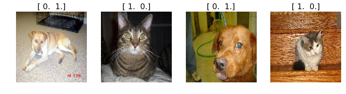

```python
plots(imgs, titles=labels)
```

We can now pass the images to Vgg16's predict() function to get back probabilities, category indexes, and category names for each image's VGG prediction.

```python
vgg.predict(imgs, True)
```

```
(array([ 0.105 ,  0.6494,  0.4536,  0.2676], dtype=float32),
 array([151, 285, 184, 249], dtype=int64),
 ['Chihuahua', 'Egyptian_cat', 'Irish_terrier', 'malamute'])
```

The category indexes are based on the ordering of categories used in the VGG model - e.g here are the first four:

```python
vgg.classes[:4]
```

```
['tench', 'goldfish', 'great_white_shark', 'tiger_shark']
```

## Use our Vgg16 class to finetune a Dogs vs Cats model

To change our model so that it outputs "cat" vs "dog", instead of one of 1,000 very specific categories, we need to use a process called "finetuning". Finetuning looks from the outside to be identical to normal machine learning training - we provide a training set with data and labels to learn from, and a validation set to test against. The model learns a set of parameters based on the data provided.

However, the difference is that we start with a model that is already trained to solve a similar problem. The idea is that many of the parameters should be very similar, or the same, between the existing model, and the model we wish to create. Therefore, we only select a subset of parameters to train, and leave the rest untouched. This happens automatically when we call *fit()* after calling *finetune()*.

We create our batches just like before, and making the validation set available as well. A 'batch' (or *mini-batch* as it is commonly known) is simply a subset of the training data - we use a subset at a time when training or predicting, in order to speed up training, and to avoid running out of memory.

```python
batch_size=64
```

```python
batches = vgg.get_batches(str(path/'train'), batch_size=batch_size)
val_batches = vgg.get_batches(str(path/'valid'), batch_size=batch_size)
```

```
Found 20000 images belonging to 2 classes.
Found 5000 images belonging to 2 classes.
```

Calling *finetune()* modifies the model such that it will be trained based on the data in the batches provided - in this case, to predict either 'dog' or 'cat'.

```python
vgg.finetune(batches)
```

Finally, we *fit()* the parameters of the model using the training data, reporting the accuracy on the validation set after every epoch. (An *epoch* is one full pass through the training data.)

```python
vgg.fit(batches, val_batches, nb_epoch=1)
```

[output not shown]

### Predict on the test data (catsdogs)

```python
test_batches = vgg.get_batches(str(path/'test'), batch_size=batch_size)
```

```
Found 12500 images belonging to 1 classes.
```

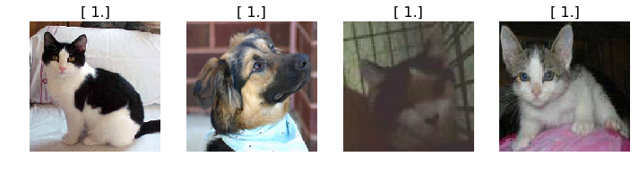

```python
imgs,labels = next(test_batches)

# This shows the 'ground truth'
plots(imgs, titles=labels)
```

```python
def pred_batch(imgs):
    preds = vgg.predict(imgs)
    idxs = np.argmax(preds, axis=1)
    print(preds)

#    print('Shape: {}'.format(preds.shape))
#    print('First 5 classes: {}'.format(classes[:5]))
#    print('First 5 probabilities: {}\n'.format(preds[0, :5]))
#    print('Predictions prob/class: ')

#    for i in range(len(idxs)):
#        idx = idxs[i]
#        print ('  {:.4f}/{}'.format(preds[i, idx], classes[idx]))
```

```python
pred_batch(imgs)
```

```
(array([ 1.,  1.,  1.,  1.], dtype=float32), array([0, 1, 0, 0], dtype=int64), ['cat', 'dog', 'cat', 'cat'])
```

### Predicting a value for all images in a folder

OK that was pretty convenient, but now we need to predict probabilities for all images in the test folder such that we can upload probabilities

```python
import glob
import pandas as pd
from keras.preprocessing import image

def predict_all(test_path, vgg):
    print(os.path.join(test_path,'*.jpg'))

    imags = glob.glob(os.path.join(test_path,'*.jpg'))
    records = []

    for n, path_img in enumerate(imags):
#        print(n)

        probs = vgg.model.predict(image.img_to_array(image.load_img(path_img, target_size=[224, 224])).reshape(1, 3, 224, 224))
        number = os.path.split(path_img)[-1][0:-4]
        records.append({'id': number, 'label': probs[0][1]})

    if n % 15 == 0:
        print(float(n) / len(imags))

    df = pd.DataFrame.from_records(records)
    df['id'] = pd.to_numeric(df['id'])
    df = df.sort_values('id')
    df.to_csv('submission.csv', index=False)
```

```python
#print(str(path))
predict_all(str(path / 'test' / 'unknown'),vgg)
```

```
data\dogscats\test\unknown\*.jpg
```

That shows all of the steps involved in using the Vgg16 class to create an image recognition model using whatever labels you are interested in. For instance, this process could classify paintings by style, or leaves by type of disease, or satellite photos by type of crop, and so forth.

Next up, we'll dig one level deeper to see what's going on in the Vgg16 class.

# Create a VGG model from scratch in Keras

For the rest of this tutorial, we will not be using the Vgg16 class at all. Instead, we will recreate from scratch the functionality we just used. This is not necessary if all you want to do is use the existing model - but if you want to create your own models, you'll need to understand these details. It will also help you in the future when you debug any problems with your models, since you'll understand what's going on behind the scenes.

## Model setup

We need to import all the modules we'll be using from numpy, scipy, and keras:

```python
from numpy.random import random, permutation
from scipy import misc, ndimage
from scipy.ndimage.interpolation import zoom

import keras
from keras import backend as K
from keras.utils.data_utils import get_file
from keras.models import Sequential, Model
from keras.layers.core import Flatten, Dense, Dropout, Lambda
from keras.layers import Input
from keras.layers.convolutional import Convolution2D, MaxPooling2D, ZeroPadding2D
from keras.optimizers import SGD, RMSprop
from keras.preprocessing import image

import simplejson as json #python3
```

Let's import the mappings from VGG ids to imagenet category ids and descriptions, for display purposes later.

```python
FILES_PATH = 'http://www.platform.ai/models/'; CLASS_FILE='imagenet_class_index.json'
# Keras' get_file() is a handy function that downloads files, and caches them for re-use later
fpath = get_file(CLASS_FILE, FILES_PATH+CLASS_FILE, cache_subdir='models')
with open(fpath) as f: class_dict = json.load(f)
# Convert dictionary with string indexes into an array
classes = [class_dict[str(i)][1] for i in range(len(class_dict))]
```

Here's a few examples of the categories we just imported:

```python
classes[:5]
```

```
['tench', 'goldfish', 'great_white_shark', 'tiger_shark', 'hammerhead']
```